# Data mining by hand

Andey Nunes

January 30, 2019

## Data Mining by Hand Exercise

```r
heritage <- readRDS("Heritage.rds")
# full Heritage.xlsx main data with "risk_group" assigned as outlined in the Homework #2 intro.
names(heritage)
```

```
##  [1] "ID"                    "MemberID"
##  [3] "ProviderID"            "vendor"
##  [5] "pcp"                   "Year"
##  [7] "specialty"             "placesvc"
##  [9] "paydelay"              "LengthOfStay"
## [11] "dsfs"                  "PrimaryConditionGroup"
## [13] "CharlsonIndex"         "sex"
## [15] "AgeAtFirstClaim"       "DaysInHospital_Y2"
## [17] "risk_group"
```

Recreate pivot table from given data Excel workbook

```r
H_pivot <- heritage %>%
   group_by(CharlsonIndex, PrimaryConditionGroup) %>%
   summarize(aveY2 = mean(DaysInHospital_Y2)) %>%
   spread(CharlsonIndex, aveY2) #%>%
   #select(1,5,3,4,2)
```

To find the 1R rule, we need know the cardinality of each grouping variable and the *purity* of each `risk_group` filtered by a single variable as shown in the text section 4.1. I’ll reuse code from homework 1 to make a table showing the attributes of each of the variables.

```r
countNA <- function(x) {sum(is.na(x)) } # count the number of missing data entries
get_range <- function(x) {ifelse(is.numeric(x), diff(range(x)), NA)}

make_partBtable <- function(x){
   df <- tibble(variable_name = names(x),
                variable_type = NA,
                variable_class = map_chr(x, class),
                count_missing = map_int(x, countNA),
                count_unique = map_dbl(x, ~length(unique(.x)) ),
                variable_range = map_dbl(x, get_range))
   return(df)

}
```

```r
H_vars <- make_partBtable(heritage)

kable(H_vars, caption = "Heritage data set variable attributes")
```

Heritage data set variable attributes

| variable_name | variable_type | variable_class | count_missing | count_unique | variable_range |
| --- | --- | --- | --- | --- | --- |
| ID | NA | numeric | 0 | 644706 | 644705 |
| MemberID | NA | numeric | 0 | 77289 | 999973441 |
| ProviderID | NA | numeric | 3903 | 7825 | NA |
| vendor | NA | numeric | 6492 | 3851 | NA |
| pcp | NA | numeric | 1619 | 1012 | NA |
| Year | NA | character | 0 | 1 | NA |
| specialty | NA | character | 0 | 12 | NA |
| placesvc | NA | character | 0 | 8 | NA |
| paydelay | NA | numeric | 44623 | 163 | NA |
| LengthOfStay | NA | character | 617827 | 13 | NA |
| dsfs | NA | character | 0 | 12 | NA |
| PrimaryConditionGroup | NA | character | 0 | 45 | NA |
| CharlsonIndex | NA | character | 0 | 4 | NA |
| sex | NA | character | 0 | 2 | NA |
| AgeAtFirstClaim | NA | character | 0 | 9 | NA |
| DaysInHospital_Y2 | NA | numeric | 0 | 16 | 15 |
| risk_group | NA | character | 0 | 3 | NA |

The first five variables are patient, doctor, and facility type identifiers that will not be useful at this time. The `Year` variable also contains no missing values and only a single unique entry, so it will also not be useful at this time. Additionally, the `paydelay` and `LengthOfStay` variables have so many missing observations, that its questionable if they are useful at this time. The `risk_group` variable is a binning of the `DaysInHospital_Y2` numeric value according to the Homework description.

- the “low” `risk_group` is `DaysInHospital_Y2` < 3
- the “med” `risk_group` is `DaysInHospital_Y2` < 6 & `DaysInHospital_Y2` >= 3
- the “high” `risk_group` is `DaysInHospital_Y2` >= 6

I’ll continue working at this time with a selected subset of the remaining variables.

```r
h_subset <- select(heritage, c("specialty", "placesvc", "dsfs", "PrimaryConditionGroup",
                               "CharlsonIndex", "sex", "LengthOfStay", "AgeAtFirstClaim",
                               "DaysInHospital_Y2", "risk_group"))
h_subset$risk_group <- ordered(h_subset$risk_group, levels = c("low","med","high"))
str(h_subset)
```

```
## Classes 'tbl_df', 'tbl' and 'data.frame':    644706 obs. of  10 variables:
##  $ specialty            : chr  "Internal" "Laboratory" "Internal" "Internal" ...
##  $ placesvc             : chr  "Office" "Independent Lab" "Office" "Office" ...
##  $ dsfs                 : chr  "0- 1 month" "0- 1 month" "1- 2 months" "2- 3 months" ...
##  $ PrimaryConditionGroup: chr  "RESPR4" "MSC2a3" "RESPR4" "RESPR4" ...
##  $ CharlsonIndex        : chr  "1-2" "0" "1-2" "1-2" ...
##  $ sex                  : chr  "F" "F" "F" "F" ...
##  $ LengthOfStay         : chr  NA NA NA NA ...
##  $ AgeAtFirstClaim      : chr  "10-19" "10-19" "10-19" "10-19" ...
##  $ DaysInHospital_Y2    : num  0 0 0 0 0 0 0 0 0 0 ...
##  $ risk_group           : Ord.factor w/ 3 levels "low"<"med"<"high": 1 1 1 1 1 1 1 1 1 1 ...
```

Now for a couple of custom functions to speed up the single variable exploration.

**graphical inspection**

```r
risk_group_counts <- ggplot(h_subset, aes(x = risk_group)) +
   geom_text(aes(label = ..count..), stat = "count", vjust = -0.25) +
   geom_bar() +
   scale_x_discrete(c("low", "med", "high"))
```

**proportion of observations for risk groups**

```r
prop_obs <- function(df = h_subset, x, y = h_subset$risk_group) {
   prop <- with(df, table(x, y))
   prop <- cbind(prop, total = rowSums(prop))
   high_prop <- prop[,3]/prop[,4]*100
   prop <- cbind(prop, high_risk_proportion = high_prop)
   #proptibble <- tibble(prop) %>%
    #  arrange(desc(high_risk_proportion))

   return(prop)
}
```

**Average `DaysInHospital_Y2`**

```r
getAveY2 <- function(df = h_subset, x,
                  y = h_subset$DaysInHospital_Y2) {
   group_by(df, by = x) %>%
      summarise(n = n(),
         aveY2 = mean(DaysInHospital_Y2)) %>%
      arrange(desc(aveY2))
}
```

#### *by specialty*

```r
kable(getAveY2(x = h_subset$specialty))
```

| by | n | aveY2 |
| --- | --- | --- |
| Emergency | 31988 | 1.32 |
| Other | 20983 | 1.31 |
| Internal | 170642 | 1.24 |
| Diagnostic Imaging | 66641 | 1.20 |
| Surgery | 53774 | 1.13 |
| Anesthesiology | 7499 | 1.10 |
| Laboratory | 124325 | 1.04 |
| Pathology | 4194 | 0.98 |
| Rehabilitation | 7282 | 0.97 |
| General Practice | 129284 | 0.89 |
| Obstetrics and Gynecology | 10419 | 0.75 |
| Pediatrics | 17675 | 0.37 |

```r
spec_prop <- prop_obs(x = h_subset$specialty)
kable(spec_prop)
```

|  | low | med | high | total | high_risk_proportion |
| --- | --- | --- | --- | --- | --- |
| Anesthesiology | 6495 | 466 | 538 | 7499 | 7.2 |
| Diagnostic Imaging | 57367 | 4014 | 5260 | 66641 | 7.9 |
| Emergency | 27215 | 2030 | 2743 | 31988 | 8.6 |
| General Practice | 115911 | 5926 | 7447 | 129284 | 5.8 |
| Internal | 146557 | 9748 | 14337 | 170642 | 8.4 |
| Laboratory | 109158 | 6545 | 8622 | 124325 | 6.9 |
| Obstetrics and Gynecology | 9201 | 878 | 340 | 10419 | 3.3 |
| Other | 17933 | 1117 | 1933 | 20983 | 9.2 |
| Pathology | 3721 | 221 | 252 | 4194 | 6.0 |
| Pediatrics | 16910 | 559 | 206 | 17675 | 1.2 |
| Rehabilitation | 6410 | 419 | 453 | 7282 | 6.2 |
| Surgery | 46773 | 2833 | 4168 | 53774 | 7.8 |

The greatest proportion `specialty` for high risk patients is 9.21% capture in the *Other* category. This isn’t very revealing, but good to note. The count chart shows that the *Internal* category captures the greatest number of high risk patients for this field.

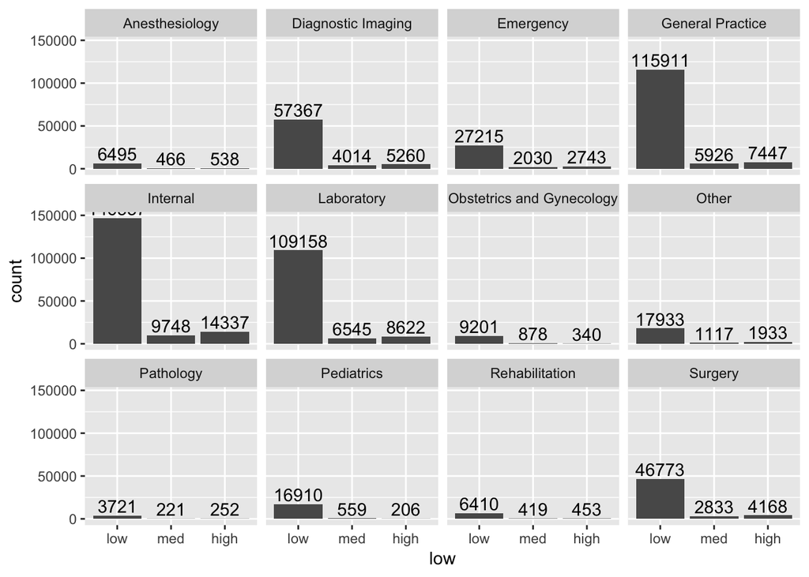

```r
risk_group_counts +
facet_wrap(~specialty)
```

#### *by placesvc*

```r
place_prop <- prop_obs(x = h_subset$placesvc)
kable(place_prop)
```

|  | low | med | high | total | high_risk_proportion |
| --- | --- | --- | --- | --- | --- |
| Ambulance | 7461 | 331 | 459 | 8251 | 5.6 |
| Home | 729 | 47 | 209 | 985 | 21.2 |
| Independent Lab | 110202 | 6655 | 8641 | 125498 | 6.9 |
| Inpatient Hospital | 16741 | 1812 | 3230 | 21783 | 14.8 |
| Office | 357414 | 20612 | 26283 | 404309 | 6.5 |
| Other | 2405 | 189 | 549 | 3143 | 17.5 |
| Outpatient Hospital | 26674 | 1942 | 2373 | 30989 | 7.7 |
| Urgent Care | 42025 | 3168 | 4555 | 49748 | 9.2 |

```r
kable(getAveY2(x = h_subset$placesvc))
```

| by | n | aveY2 |
| --- | --- | --- |
| Home | 985 | 2.79 |
| Other | 3143 | 2.43 |
| Inpatient Hospital | 21783 | 2.12 |
| Urgent Care | 49748 | 1.38 |
| Outpatient Hospital | 30989 | 1.18 |
| Independent Lab | 125498 | 1.03 |
| Office | 404309 | 0.99 |
| Ambulance | 8251 | 0.86 |

The greatest proportion of `placesvc` for high risk patients is 21.22% captured in the *Home* category. The count charts show that the *Office* category captures the greatest number of high risk patients for this field.

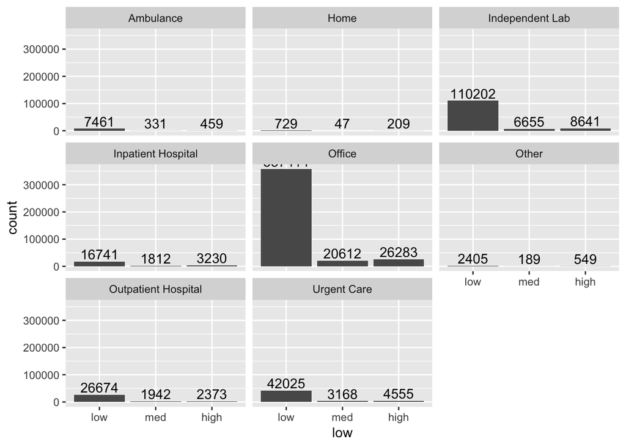

```r
risk_group_counts +
   facet_wrap(~placesvc)
```

#### *by dsfs*

```r
kable(getAveY2(x = h_subset$dsfs))
```

| by | n | aveY2 |
| --- | --- | --- |
| 11-12 months | 10697 | 1.56 |
| 10-11 months | 27632 | 1.39 |
| 9-10 months | 36404 | 1.27 |
| 8- 9 months | 40910 | 1.21 |
| 6- 7 months | 43834 | 1.19 |
| 7- 8 months | 42285 | 1.18 |
| 4- 5 months | 46923 | 1.18 |
| 5- 6 months | 46839 | 1.18 |
| 3- 4 months | 52594 | 1.15 |
| 2- 3 months | 56464 | 1.12 |
| 1- 2 months | 63077 | 1.08 |
| 0- 1 month | 177047 | 0.82 |

```r
dsfs_prop <- prop_obs(x = h_subset$dsfs)
kable(dsfs_prop)
```

|  | low | med | high | total | high_risk_proportion |
| --- | --- | --- | --- | --- | --- |
| 0- 1 month | 160188 | 7766 | 9093 | 177047 | 5.1 |
| 1- 2 months | 55230 | 3394 | 4453 | 63077 | 7.1 |
| 10-11 months | 23270 | 1663 | 2699 | 27632 | 9.8 |
| 11-12 months | 8758 | 738 | 1201 | 10697 | 11.2 |
| 2- 3 months | 49033 | 3261 | 4170 | 56464 | 7.4 |
| 3- 4 months | 45524 | 3084 | 3986 | 52594 | 7.6 |
| 4- 5 months | 40560 | 2717 | 3646 | 46923 | 7.8 |
| 5- 6 months | 40561 | 2616 | 3662 | 46839 | 7.8 |
| 6- 7 months | 37723 | 2607 | 3504 | 43834 | 8.0 |
| 7- 8 months | 36554 | 2356 | 3375 | 42285 | 8.0 |
| 8- 9 months | 35164 | 2437 | 3309 | 40910 | 8.1 |
| 9-10 months | 31086 | 2117 | 3201 | 36404 | 8.8 |

The greatest proportion of `dsfs` for high risk patients is 11.23% capture in the *11-12 months* category, however, these percentages were all very close together. The count charts show that the *0-1 month* category captures the greatest number of high risk patients.

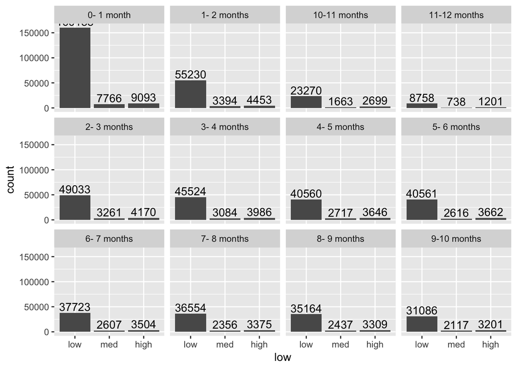

```r
risk_group_counts +
   facet_wrap(~dsfs)
```

#### *by PrimaryConditionGroup*

```r
kable(getAveY2(x = h_subset$PrimaryConditionGroup))
```

| by | n | aveY2 |
| --- | --- | --- |
| RENAL2 | 2103 | 2.83 |
| CHF | 3172 | 2.35 |
| RENAL1 | 124 | 2.15 |
| CATAST | 445 | 2.02 |
| SEPSIS | 120 | 1.93 |
| AMI | 8891 | 1.84 |
| HIPFX | 1023 | 1.82 |
| HEART2 | 12419 | 1.76 |
| CANCRM | 231 | 1.70 |
| HEMTOL | 6194 | 1.65 |
| STROKE | 2149 | 1.65 |
| ROAMI | 12835 | 1.59 |
| FLaELEC | 1247 | 1.57 |
| SEIZURE | 5162 | 1.47 |
| COPD | 11706 | 1.43 |
| PNEUM | 2581 | 1.40 |
| HEART4 | 7077 | 1.39 |
| CANCRA | 1101 | 1.33 |
| CANCRB | 9739 | 1.33 |
| GIBLEED | 28846 | 1.33 |
| METAB1 | 1024 | 1.27 |
| PERVALV | 850 | 1.27 |
| PRGNCY | 7833 | 1.24 |
| PNCRDZ | 259 | 1.16 |
| MISCL1 | 1301 | 1.14 |
| RENAL3 | 12749 | 1.14 |
| MISCHRT | 31421 | 1.13 |
| APPCHOL | 5041 | 1.12 |
| MISCL5 | 12315 | 1.09 |
| NEUMENT | 46305 | 1.07 |
| ARTHSPIN | 71711 | 1.06 |
| UTI | 10155 | 1.05 |
| METAB3 | 71800 | 1.04 |
| GIOBSENT | 2831 | 1.02 |
| LIVERDZ | 750 | 1.01 |
| SKNAUT | 26901 | 0.98 |
| RESPR4 | 37533 | 0.88 |
| MSC2a3 | 111499 | 0.88 |
| TRAUMA | 18960 | 0.87 |
| INFEC4 | 21541 | 0.86 |
| GYNECA | 2369 | 0.84 |
| FXDISLC | 8682 | 0.83 |
| ODaBNCA | 12316 | 0.82 |
| PERINTL | 161 | 0.81 |
| GYNEC1 | 11234 | 0.76 |

```r
pcg_prop <- prop_obs(x = h_subset$PrimaryConditionGroup)
kable(pcg_prop)
```

|  | low | med | high | total | high_risk_proportion |
| --- | --- | --- | --- | --- | --- |
| AMI | 6931 | 772 | 1188 | 8891 | 13.4 |
| APPCHOL | 4404 | 282 | 355 | 5041 | 7.0 |
| ARTHSPIN | 62494 | 4344 | 4873 | 71711 | 6.8 |
| CANCRA | 953 | 47 | 101 | 1101 | 9.2 |
| CANCRB | 8264 | 531 | 944 | 9739 | 9.7 |
| CANCRM | 194 | 15 | 22 | 231 | 9.5 |
| CATAST | 356 | 21 | 68 | 445 | 15.3 |
| CHF | 2414 | 195 | 563 | 3172 | 17.8 |
| COPD | 9807 | 700 | 1199 | 11706 | 10.2 |
| FLaELEC | 1026 | 77 | 144 | 1247 | 11.6 |
| FXDISLC | 7864 | 348 | 470 | 8682 | 5.4 |
| GIBLEED | 24637 | 1685 | 2524 | 28846 | 8.8 |
| GIOBSENT | 2513 | 129 | 189 | 2831 | 6.7 |
| GYNEC1 | 9913 | 942 | 379 | 11234 | 3.4 |
| GYNECA | 2135 | 128 | 106 | 2369 | 4.5 |
| HEART2 | 9962 | 866 | 1591 | 12419 | 12.8 |
| HEART4 | 5995 | 356 | 726 | 7077 | 10.3 |
| HEMTOL | 5098 | 339 | 757 | 6194 | 12.2 |
| HIPFX | 828 | 65 | 130 | 1023 | 12.7 |
| INFEC4 | 19430 | 972 | 1139 | 21541 | 5.3 |
| LIVERDZ | 667 | 35 | 48 | 750 | 6.4 |
| METAB1 | 873 | 65 | 86 | 1024 | 8.4 |
| METAB3 | 63300 | 3460 | 5040 | 71800 | 7.0 |
| MISCHRT | 27414 | 1570 | 2437 | 31421 | 7.8 |
| MISCL1 | 1137 | 66 | 98 | 1301 | 7.5 |
| MISCL5 | 10712 | 736 | 867 | 12315 | 7.0 |
| MSC2a3 | 99929 | 5217 | 6353 | 111499 | 5.7 |
| NEUMENT | 40820 | 2142 | 3343 | 46305 | 7.2 |
| ODaBNCA | 11135 | 524 | 657 | 12316 | 5.3 |
| PERINTL | 141 | 10 | 10 | 161 | 6.2 |
| PERVALV | 698 | 67 | 85 | 850 | 10.0 |
| PNCRDZ | 219 | 20 | 20 | 259 | 7.7 |
| PNEUM | 2206 | 149 | 226 | 2581 | 8.8 |
| PRGNCY | 6106 | 1298 | 429 | 7833 | 5.5 |
| RENAL1 | 100 | 6 | 18 | 124 | 14.5 |
| RENAL2 | 1564 | 110 | 429 | 2103 | 20.4 |
| RENAL3 | 11027 | 750 | 972 | 12749 | 7.6 |
| RESPR4 | 33809 | 1662 | 2062 | 37533 | 5.5 |
| ROAMI | 10469 | 913 | 1453 | 12835 | 11.3 |
| SEIZURE | 4367 | 337 | 458 | 5162 | 8.9 |
| SEPSIS | 90 | 13 | 17 | 120 | 14.2 |
| SKNAUT | 23901 | 1216 | 1784 | 26901 | 6.6 |
| STROKE | 1772 | 141 | 236 | 2149 | 11.0 |
| TRAUMA | 17099 | 838 | 1023 | 18960 | 5.4 |
| UTI | 8878 | 597 | 680 | 10155 | 6.7 |

The greatest proportion of `PrimaryConditionGroup` for high risk patients is 20.4% capture in the *RENAL2* category. The count charts show that the *MSC2a3* category captures the greatest number of high risk patients.

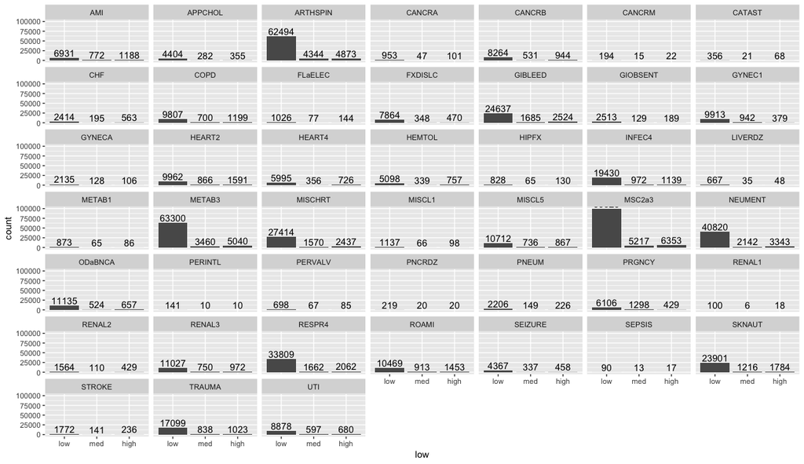

caption = “PrimaryConditionGroup”

```r
risk_group_counts +
   facet_wrap(~PrimaryConditionGroup)

ggsave(filename="PrimaryConditionGroup.png",
       width = 8, height = 6,
       units = "in", # other options are "in", "cm", "mm"
       dpi = 200
       )
# the html render of the ggplot object was terrible, so I made it bigger and saved it, then recall it below
```

#### *by Charlson Index*

```r
kable(getAveY2(x = h_subset$CharlsonIndex))
```

| by | n | aveY2 |
| --- | --- | --- |
| 3-4 | 10780 | 2.14 |
| 5+ | 1211 | 1.82 |
| 1-2 | 263524 | 1.52 |
| 0 | 369191 | 0.74 |

```r
ci_prop <- prop_obs(x = h_subset$CharlsonIndex)

kable(ci_prop)
```

|  | low | med | high | total | high_risk_proportion |
| --- | --- | --- | --- | --- | --- |
| 0 | 335579 | 17561 | 16051 | 369191 | 4.3 |
| 1-2 | 218765 | 16352 | 28407 | 263524 | 10.8 |
| 3-4 | 8327 | 752 | 1701 | 10780 | 15.8 |
| 5+ | 980 | 91 | 140 | 1211 | 11.6 |

The greatest proportion of `CharlsonIndex` for high risk patients is 15.78% capture in the *3-4* category. The count charts show that the *1-2* category captures the greatest number of high risk patients.

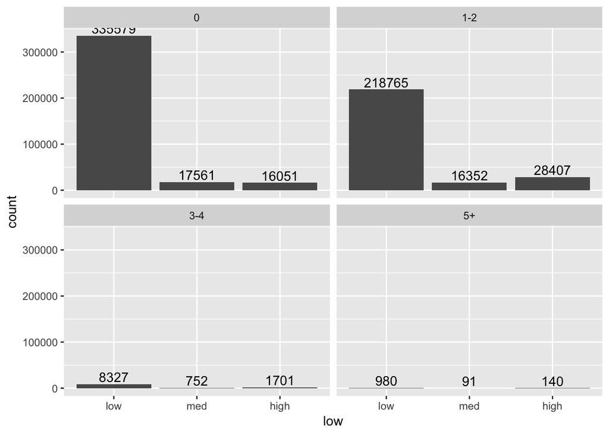

```r
risk_group_counts +
   facet_wrap(~CharlsonIndex)
```

#### *by sex*

```r
kable(getAveY2(x = h_subset$sex))
```

| by | n | aveY2 |
| --- | --- | --- |
| F | 378963 | 1.1 |
| M | 265743 | 1.1 |

```r
sex_prop <- prop_obs(x = h_subset$sex)

kable(sex_prop)
```

|  | low | med | high | total | high_risk_proportion |
| --- | --- | --- | --- | --- | --- |
| F | 330055 | 22059 | 26849 | 378963 | 7.1 |
| M | 233596 | 12697 | 19450 | 265743 | 7.3 |

The greatest proportion of `sex` for high risk patients is 7.32% capture in the *M* category, however, these catagories are very close and might not be of any use in distinguishing sets of observations. The count charts show that the *F* category captures the greatest number of high risk patients, however, that state also has more patients in every category than the *M* state. I think this confirms the move to disregard this variable as a potential rule maker.

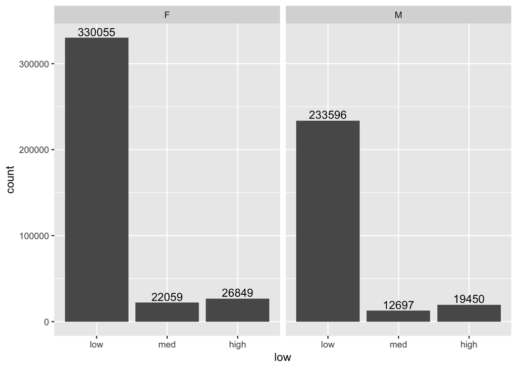

```r
risk_group_counts +
   facet_wrap(~sex)
```

#### *by LengthOfStay*

```r
kable(getAveY2(x = h_subset$LengthOfStay))
```

| by | n | aveY2 |
| --- | --- | --- |
| 8-12 weeks | 11 | 3.73 |
| 4- 8 weeks | 245 | 3.37 |
| 1- 2 weeks | 302 | 3.23 |
| 2- 4 weeks | 185 | 3.03 |
| 26+ weeks | 12 | 2.33 |
| 5 days | 211 | 1.91 |
| 2 days | 2162 | 1.61 |
| 4 days | 466 | 1.41 |
| 3 days | 896 | 1.38 |
| 1 day | 22281 | 1.36 |
| 6 days | 99 | 1.31 |
| NA | 617827 | 1.07 |
| 12-26 weeks | 9 | 0.67 |

```r
los_prop <- prop_obs(x = h_subset$LengthOfStay)

kable(los_prop)
```

|  | low | med | high | total | high_risk_proportion |
| --- | --- | --- | --- | --- | --- |
| 1 day | 18879 | 1434 | 1968 | 22281 | 8.8 |
| 1- 2 weeks | 211 | 19 | 72 | 302 | 23.8 |
| 12-26 weeks | 8 | 1 | 0 | 9 | 0.0 |
| 2 days | 1769 | 161 | 232 | 2162 | 10.7 |
| 2- 4 weeks | 132 | 10 | 43 | 185 | 23.2 |
| 26+ weeks | 9 | 0 | 3 | 12 | 25.0 |
| 3 days | 750 | 60 | 86 | 896 | 9.6 |
| 4 days | 389 | 37 | 40 | 466 | 8.6 |
| 4- 8 weeks | 174 | 3 | 68 | 245 | 27.8 |
| 5 days | 161 | 26 | 24 | 211 | 11.4 |
| 6 days | 89 | 1 | 9 | 99 | 9.1 |
| 8-12 weeks | 8 | 0 | 3 | 11 | 27.3 |

The greatest proportion of `LengthOfStay` for high risk patients is 27.76% capture in the *4-8 weeks* category. The count charts show that the *1 day* category captures the greatest number of high risk patients.

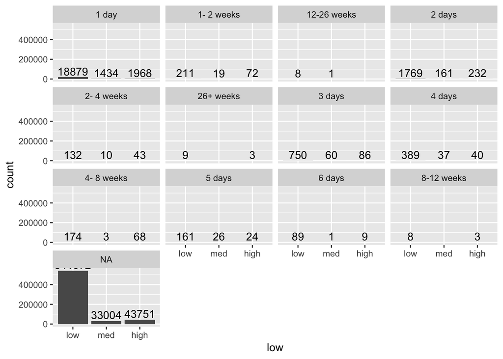

```r
risk_group_counts +
   facet_wrap(~LengthOfStay)
```

#### *by AgeAtFirstClaim*

```r
kable(getAveY2(x = h_subset$AgeAtFirstClaim))
```

| by | n | aveY2 |
| --- | --- | --- |
| 80+ | 101319 | 1.99 |
| 70-79 | 170799 | 1.40 |
| 60-69 | 100934 | 1.00 |
| 20-29 | 25652 | 0.80 |
| 30-39 | 44739 | 0.72 |
| 50-59 | 75146 | 0.67 |
| 40-49 | 71580 | 0.50 |
| 0-9 | 26740 | 0.36 |
| 10-19 | 27797 | 0.36 |

```r
aafc_prop <- prop_obs(x = h_subset$AgeAtFirstClaim)

kable(aafc_prop)
```

|  | low | med | high | total | high_risk_proportion |
| --- | --- | --- | --- | --- | --- |
| 0-9 | 25820 | 571 | 349 | 26740 | 1.3 |
| 10-19 | 26571 | 871 | 355 | 27797 | 1.3 |
| 20-29 | 22480 | 2291 | 881 | 25652 | 3.4 |
| 30-39 | 40097 | 3063 | 1579 | 44739 | 3.5 |
| 40-49 | 67039 | 2725 | 1816 | 71580 | 2.5 |
| 50-59 | 69097 | 3084 | 2965 | 75146 | 4.0 |
| 60-69 | 89528 | 4671 | 6735 | 100934 | 6.7 |
| 70-79 | 144026 | 10213 | 16560 | 170799 | 9.7 |
| 80+ | 78993 | 7267 | 15059 | 101319 | 14.9 |

The greatest proportion of `AgeAtFirstClaim` for high risk patients is 14.86% capture in the *80+* category. The count charts show that the *70-79* category captures the greatest number of high risk patients.

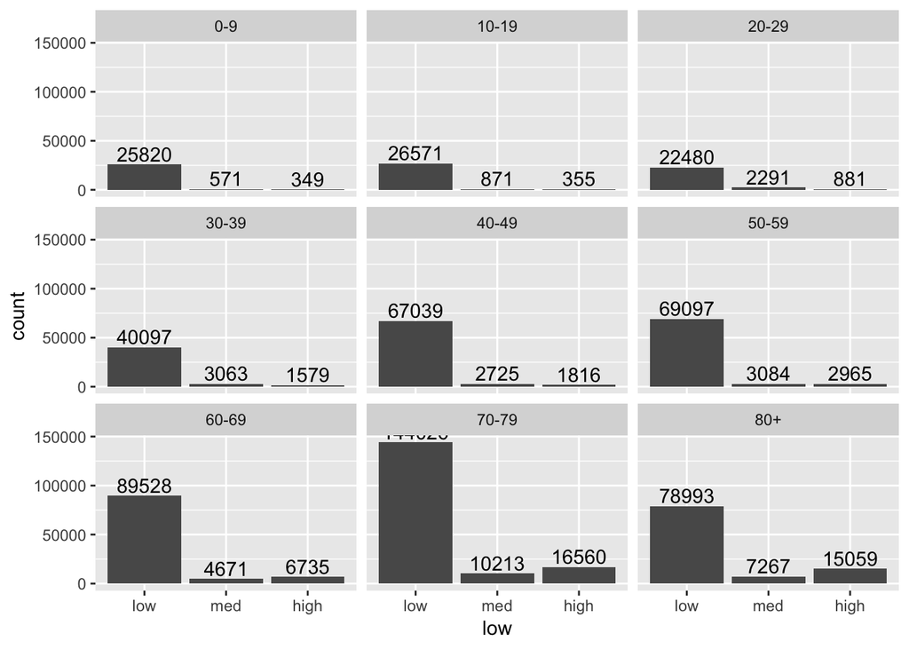

```r
risk_group_counts +
   facet_wrap(~AgeAtFirstClaim)
```

Several categories present opportunities for re-binning the factors and could improve the rule predictions, for example the `AgeAtFirstClaim` field has 9 states that could be recombined to 3 states, 0-29, 30-59, 60+, which may result in the loss of some information, but might be justifiable for sake of simple rules.

### 1R rule set

We’ve already completed that first part, now we select some variables worth considering given the grouped average `DaysInHospital_Y2`, grouped frequency counts, and proportion of high risk patients in each state from the exploration above. Then calculate the error rate and see if we can eliminiate any (choose the smallest).

For starters on the 1R set, lets choose fields where the `aveY2` value from the above tables is greater than 2.5.

> LengthOfStay == 8-12 weeks PrimaryConditionGroup == RENAL2 placesvc == Home

I believe we could do better with the first two elements of this 1R rule set if we could reduce the cardinality of the variables and regroup the categories down to say, only four to six options, but that’s probably for another assignment.

### 2R rule set

I will rerun the grouped `aveY2` for each pair of fields where the top state `aveY2` value is greater than 2 days.

```r
ci_los <- h_subset %>%
   group_by(CharlsonIndex, LengthOfStay) %>%
   summarise(n = n(),
      aveY2 = mean(DaysInHospital_Y2)) %>%
   filter(aveY2 > 4 & n > 1) %>%
   arrange(desc(aveY2)) %>%
   head()

kable(ci_los)
```

| CharlsonIndex | LengthOfStay | n | aveY2 |
| --- | --- | --- | --- |
| 5+ | 6 days | 3 | 8.0 |
| 3-4 | 5 days | 7 | 7.1 |
| 1-2 | 8-12 weeks | 7 | 5.9 |
| 5+ | 3 days | 3 | 5.0 |
| 5+ | 4 days | 4 | 4.5 |
| 3-4 | 2 days | 33 | 4.4 |

```r
pcg_los <- h_subset %>%
   group_by(PrimaryConditionGroup, LengthOfStay) %>%
   summarise(n = n(),
      aveY2 = mean(DaysInHospital_Y2)) %>%
   filter(aveY2 > 4 & n > 1) %>%
   arrange(desc(aveY2)) %>%
   head(20)

kable(pcg_los)
```

| PrimaryConditionGroup | LengthOfStay | n | aveY2 |
| --- | --- | --- | --- |
| CHF | 8-12 weeks | 2 | 13.0 |
| CANCRM | 1 day | 3 | 10.0 |
| SEPSIS | 2 days | 2 | 10.0 |
| HEART4 | 1- 2 weeks | 4 | 9.0 |
| RENAL3 | 1- 2 weeks | 6 | 8.5 |
| MISCL1 | 2- 4 weeks | 2 | 7.5 |
| CHF | 3 days | 5 | 6.4 |
| TRAUMA | 2- 4 weeks | 3 | 6.3 |
| CANCRB | 5 days | 7 | 6.3 |
| FXDISLC | 2- 4 weeks | 4 | 6.2 |
| COPD | 4 days | 11 | 6.2 |
| TRAUMA | 5 days | 3 | 6.0 |
| CATAST | 2 days | 3 | 5.7 |
| GIBLEED | 1- 2 weeks | 9 | 5.6 |
| COPD | 4- 8 weeks | 2 | 5.5 |
| METAB3 | 1- 2 weeks | 5 | 5.4 |
| PNEUM | 5 days | 5 | 5.4 |
| RENAL2 | 1 day | 10 | 5.2 |
| SKNAUT | 1- 2 weeks | 6 | 5.2 |
| METAB3 | 2 days | 24 | 4.8 |

```r
dsfs_los <- h_subset %>%
   group_by(dsfs, LengthOfStay) %>%
   summarise(n = n(),
      aveY2 = mean(DaysInHospital_Y2)) %>%
   filter(aveY2 > 4 & n > 1) %>%
   arrange(desc(aveY2)) %>%
   head()

kable(dsfs_los)
```

| dsfs | LengthOfStay | n | aveY2 |
| --- | --- | --- | --- |
| 7- 8 months | 8-12 weeks | 2 | 13.0 |
| 11-12 months | 1- 2 weeks | 4 | 7.8 |
| 10-11 months | 2- 4 weeks | 4 | 6.2 |
| 1- 2 months | 1- 2 weeks | 39 | 5.2 |
| 5- 6 months | 2- 4 weeks | 12 | 4.8 |
| 2- 3 months | 4- 8 weeks | 17 | 4.7 |

```r
spec_los <- h_subset %>%
   group_by(specialty, LengthOfStay) %>%
   summarise(n = n(),
      aveY2 = mean(DaysInHospital_Y2)) %>%
   filter(aveY2 > 4 & n > 1) %>%
   arrange(desc(aveY2)) %>%
   head()

kable(spec_los)
```

| specialty | LengthOfStay | n | aveY2 |
| --- | --- | --- | --- |
| Internal | 8-12 weeks | 4 | 6.5 |
| Laboratory | 1 day | 33 | 5.9 |
| Emergency | 26+ weeks | 3 | 5.0 |
| Internal | 2- 4 weeks | 62 | 4.7 |
| Internal | 26+ weeks | 3 | 4.3 |
| Internal | 4- 8 weeks | 172 | 4.2 |

```r
psvc_pcg <- h_subset %>%
   group_by(placesvc, PrimaryConditionGroup) %>%
   summarise(n = n(),
      aveY2 = mean(DaysInHospital_Y2)) %>%
   filter(aveY2 > 4 & n > 1) %>%
   arrange(desc(aveY2)) %>%
   head()
 kable(psvc_pcg)
```

| placesvc | PrimaryConditionGroup | n | aveY2 |
| --- | --- | --- | --- |
| Home | LIVERDZ | 5 | 15.0 |
| Home | ODaBNCA | 4 | 8.8 |
| Home | RENAL2 | 8 | 8.8 |
| Home | APPCHOL | 3 | 6.7 |
| Ambulance | METAB3 | 15 | 5.7 |
| Other | GYNECA | 4 | 5.5 |

```r
ci_pcg <- h_subset %>%
   group_by(CharlsonIndex, PrimaryConditionGroup) %>%
   summarise(n = n(),
      aveY2 = mean(DaysInHospital_Y2)) %>%
   filter(aveY2 > 4 & n > 1) %>%
   arrange(desc(aveY2)) %>%
   head()
kable(ci_pcg) # essentially the pivot table results
```

| CharlsonIndex | PrimaryConditionGroup | n | aveY2 |
| --- | --- | --- | --- |
| 5+ | HIPFX | 3 | 14.0 |
| 5+ | APPCHOL | 5 | 8.4 |
| 5+ | MISCL1 | 2 | 7.5 |
| 3-4 | CATAST | 13 | 7.0 |
| 5+ | HEART2 | 20 | 5.7 |
| 3-4 | CANCRM | 2 | 5.5 |

## 3R Rule Set

```r
los_age_ci <- h_subset %>%
   group_by(LengthOfStay,AgeAtFirstClaim, CharlsonIndex) %>%
   summarise(n = n(),
      aveY2 = mean(DaysInHospital_Y2)) %>%
   filter(aveY2 > 4 & n > 1) %>%
   arrange(desc(aveY2)) %>%
   head(20)
#)
kable(los_age_ci)
```

| LengthOfStay | AgeAtFirstClaim | CharlsonIndex | n | aveY2 |
| --- | --- | --- | --- | --- |
| 2 days | 50-59 | 3-4 | 2 | 15.0 |
| 2- 4 weeks | 30-39 | 1-2 | 2 | 15.0 |
| 5 days | 70-79 | 3-4 | 4 | 11.2 |
| 2- 4 weeks | 70-79 | 0 | 11 | 7.5 |
| 1 day | 40-49 | 5+ | 4 | 7.5 |
| 1- 2 weeks | 30-39 | 1-2 | 2 | 7.5 |
| 1- 2 weeks | 70-79 | 3-4 | 2 | 7.5 |
| 4 days | 0-9 | 1-2 | 7 | 7.1 |
| 4- 8 weeks | 40-49 | 1-2 | 45 | 7.1 |
| 8-12 weeks | 80+ | 1-2 | 4 | 6.5 |
| 2- 4 weeks | 40-49 | 1-2 | 9 | 6.4 |
| 2- 4 weeks | 80+ | 3-4 | 4 | 6.2 |
| 6 days | 60-69 | 5+ | 2 | 6.0 |
| 1 day | 50-59 | 3-4 | 8 | 5.6 |
| 2 days | 70-79 | 3-4 | 15 | 5.0 |
| 26+ weeks | 70-79 | 1-2 | 3 | 5.0 |
| 8-12 weeks | 70-79 | 1-2 | 3 | 5.0 |
| 4- 8 weeks | 80+ | 0 | 6 | 4.8 |
| 1- 2 weeks | 50-59 | 1-2 | 11 | 4.6 |
| 1- 2 weeks | 80+ | 1-2 | 90 | 4.4 |

> IF LengthOfStay == “4-8 weeks” & AgeAtFirstClaim == “40-49” & CharlsonIndex == “1-2” THEN avgY2 = 7.1: n = 45

```r
los_pcg_ci <-
   #kable(
      h_subset %>%
   group_by(LengthOfStay,PrimaryConditionGroup, CharlsonIndex) %>%
   summarise(n = n(),
      aveY2 = mean(DaysInHospital_Y2)) %>%
   filter(aveY2 > 4 & n > 5) %>%
   arrange(desc(aveY2)) %>%
   head(15)
#)
 kable(los_pcg_ci)
```

| LengthOfStay | PrimaryConditionGroup | CharlsonIndex | n | aveY2 |
| --- | --- | --- | --- | --- |
| 1 day | TRAUMA | 3-4 | 7 | 8.7 |
| 1- 2 weeks | GIBLEED | 1-2 | 6 | 7.8 |
| 1 day | MISCHRT | 3-4 | 6 | 7.7 |
| NA | CATAST | 3-4 | 12 | 6.6 |
| 4 days | COPD | 1-2 | 11 | 6.2 |
| 3 days | PNEUM | 0 | 7 | 6.1 |
| 1 day | MISCL5 | 3-4 | 9 | 5.9 |
| 1 day | SEPSIS | 1-2 | 7 | 5.7 |
| 1- 2 weeks | MSC2a3 | 1-2 | 36 | 5.7 |
| NA | HEART2 | 5+ | 20 | 5.7 |
| 1- 2 weeks | APPCHOL | 0 | 6 | 5.3 |
| 2 days | METAB3 | 1-2 | 13 | 5.3 |
| 6 days | MSC2a3 | 1-2 | 8 | 5.2 |
| 1 day | RENAL2 | 1-2 | 10 | 5.2 |
| 3 days | UTI | 1-2 | 12 | 5.1 |

> LengthOfStay == “1-2 weeks” & PrimaryConditionGroup == “MSC2a3” & Charlson Index THEN avgY2 = 5.7: n = 36

? could maybe look at the HEART2 condition with 5+ CharlsonIndex also

```r
los_dsfs_ci <-
#   kable(
      h_subset %>%
   group_by(LengthOfStay,dsfs, CharlsonIndex) %>%
   summarise(n = n(),
      aveY2 = mean(DaysInHospital_Y2)) %>%
   filter(aveY2 > 4 & n > 1) %>%
   arrange(desc(aveY2)) %>%
   head(20)
#)
kable(los_dsfs_ci)
```

| LengthOfStay | dsfs | CharlsonIndex | n | aveY2 |
| --- | --- | --- | --- | --- |
| 8-12 weeks | 7- 8 months | 1-2 | 2 | 13.0 |
| 2- 4 weeks | 1- 2 months | 3-4 | 2 | 9.0 |
| 2 days | 5- 6 months | 3-4 | 5 | 8.4 |
| 1- 2 weeks | 11-12 months | 1-2 | 3 | 7.7 |
| 2- 4 weeks | 4- 5 months | 0 | 2 | 7.5 |
| 4- 8 weeks | 1- 2 months | 0 | 2 | 7.5 |
| 3 days | 9-10 months | 3-4 | 3 | 7.3 |
| 2 days | 4- 5 months | 3-4 | 4 | 7.2 |
| 1 day | 2- 3 months | 5+ | 5 | 7.0 |
| 2 days | 9-10 months | 3-4 | 2 | 6.5 |
| 5 days | 4- 5 months | 1-2 | 10 | 6.4 |
| 2- 4 weeks | 10-11 months | 1-2 | 4 | 6.2 |
| 3 days | 4- 5 months | 3-4 | 4 | 6.2 |
| 1 day | 7- 8 months | 3-4 | 7 | 6.0 |
| 6 days | 2- 3 months | 5+ | 2 | 6.0 |
| 1- 2 weeks | 1- 2 months | 1-2 | 26 | 5.9 |
| 1- 2 weeks | 10-11 months | 0 | 2 | 5.5 |
| 2- 4 weeks | 6- 7 months | 1-2 | 6 | 5.5 |
| 6 days | 9-10 months | 1-2 | 3 | 5.3 |
| 2- 4 weeks | 5- 6 months | 1-2 | 11 | 5.2 |

> IF LengthOfStay == “1-2 weeks” & dsfs == “1-2 months” & CharlsonIndex == “1-2” THEN avgY2 = 5.9: n = 26

```r
los_psvc_ci <-
#   kable(
      h_subset %>%
   group_by(LengthOfStay,placesvc, CharlsonIndex) %>%
   summarise(n = n(),
      aveY2 = mean(DaysInHospital_Y2)) %>%
   filter(aveY2 > 4 & n > 1) %>%
   arrange(desc(aveY2)) %>%
   head(10)
#)
 kable(los_psvc_ci)
```

| LengthOfStay | placesvc | CharlsonIndex | n | aveY2 |
| --- | --- | --- | --- | --- |
| 8-12 weeks | Inpatient Hospital | 1-2 | 2 | 13.0 |
| 6 days | Inpatient Hospital | 5+ | 3 | 8.0 |
| 26+ weeks | Urgent Care | 1-2 | 2 | 7.5 |
| 8-12 weeks | Home | 1-2 | 2 | 7.5 |
| 2- 4 weeks | Outpatient Hospital | 0 | 15 | 6.3 |
| 5 days | Inpatient Hospital | 3-4 | 6 | 5.8 |
| 1 day | Inpatient Hospital | 3-4 | 10 | 5.8 |
| 1 day | Home | 0 | 9 | 5.8 |
| 1- 2 weeks | Other | 3-4 | 3 | 5.3 |
| 2- 4 weeks | Inpatient Hospital | 1-2 | 3 | 5.3 |

```r
los_spec_ci <-
#   kable(
      h_subset %>%
   group_by(LengthOfStay,specialty, CharlsonIndex) %>%
   summarise(n = n(),
      aveY2 = mean(DaysInHospital_Y2)) %>%
   filter(aveY2 > 4 & n > 1) %>%
   arrange(desc(aveY2)) %>%
   head(10)
#)
 kable(los_spec_ci)
```

| LengthOfStay | specialty | CharlsonIndex | n | aveY2 |
| --- | --- | --- | --- | --- |
| 8-12 weeks | Internal | 1-2 | 3 | 8.7 |
| 1 day | Laboratory | 1-2 | 19 | 8.4 |
| 6 days | Internal | 5+ | 3 | 8.0 |
| 26+ weeks | Emergency | 1-2 | 2 | 7.5 |
| 1 day | Surgery | 5+ | 5 | 6.2 |
| 4 days | Surgery | 0 | 2 | 6.0 |
| 5 days | Internal | 3-4 | 6 | 5.8 |
| 2- 4 weeks | Internal | 0 | 20 | 5.0 |
| 3 days | Internal | 5+ | 3 | 5.0 |
| 2 days | Internal | 3-4 | 31 | 4.7 |

Add more here…